# R Notebook

#### Capstone Project - Google Data Analytics Certificate submission

#### Data Scientist - Ola Sanusi, PhD

#### Date - September 2021

## Introduction

In an effort to maximize the number of annual membership, Cyclistic bikes want to understand the difference between casual riders and riders with annual membership. The goal is to use every skills I learned about Data Analytics and historical bike trip data to understand how to convert casual riders into annual members by understanding how annual members and casual members differ, why casual riders would buy a membership and how to use digital media to attract more customers.

## Problem Statement

Cyclistics bikes believes that maximizing the number of their annual members is very important for the company’s future growth because annual members are more profitable than casual riders. Cyclistics want to understand how casual riders differ from annual members and use this findings to effectively design appropriate marketing strategy to help convert casual riders into annual members.

## Bike Trip Data

The bike trip data used in this case study was downloaded from [divy tripdata S3 bucket](https://divvy-tripdata.s3.amazonaws.com/index.html) which houses historical trip data for several years. Twelve (12) months of data covering September 2020 to August 2021 were downloaded into a folder. The zipped files (178 MB) were unzipped and each file renamed YYYYMM_bike_trips.csv (870 MB). Microsoft (MS) Excel was used for initial data preprocessing. Each file was opened and additional features (ride_length, day_of_week) created. The Start_at and Ended_at columns were formatted as Time in the format MM/DD/YY H:MM PM (3/14/01 1:30 PM) while the ride_length column formated as Time in the format HH:MM:SS (37:30:55). Each preprocessed file was saved as an Excel workbook in a subfolder.

## Data Wrangling and Visualization

Subsequent data wrangling and cleaning of each of the 12 Excel workbook file was completed using R.

```r
#load all required libraries
library(tidyverse) # to wrangle data
library(lubridate) # to wrangle date
library(janitor)
library(openxlsx)  # to work with excel worksheet
library(readxl)    # to read excel files
```

#### STEP 1 - Combine Files into a Single File

```r
# The 12 excel worksheet were merged into a single excel workbook
path <- "C:/Users/lanre/Desktop/R/Bike Data/processed_datasets"
merge_file_name <- "C:/Users/lanre/Desktop/R/Bike Data/processed_datasets//merged_file.xlsx"

filenames_list <- list.files(path= path, full.names=TRUE)

All <- lapply(filenames_list,function(filename){
  print(paste("Merging",filename,sep = " "))
  read.xlsx(filename)
})

df <- do.call(rbind.data.frame, All)
write.xlsx(df,merge_file_name)
```

### STEP 2 - Data Wrangling and Cleaning

```r
# load the single excel file as a data.frame

# specify the path of the merged xlsx file
path <- "C:/Users/lanre/Desktop/R/Bike Data/processed_datasets/merged_file.xlsx"

# Import the XLSX file
df <- read_excel(path)

# print the few rows of the file
head(df)
```

| ride_id | rideable_type | started_at | ended_at | start_station_name | start_station_id | end_station_name | end_station_id | start_lat | start_lng | end_lat | end_lng | member_casual | ride_length | day_of_week |
| --- | --- | --- | --- | --- | --- | --- | --- | --- | --- | --- | --- | --- | --- | --- |
| 2B22BD5F95FB2629 | electric_bike | 44091.60 | 44091.61 | Michigan Ave & Lake St | 52 | Green St & Randolph St | 112 | 41.88669 | -87.62356 | 41.88357 | -87.64873 | casual | 0.0119560185 | 5 |
| A7FB70B4AFC6CAF2 | electric_bike | 44091.63 | 44091.63 | W Oakdale Ave & N Broadway | NA | W Oakdale Ave & N Broadway | NA | 41.94000 | -87.64000 | 41.94000 | -87.64000 | casual | 0.0001620370 | 5 |
| 86057FA01BAC778E | electric_bike | 44091.63 | 44091.63 | W Oakdale Ave & N Broadway | NA | W Oakdale Ave & N Broadway | NA | 41.94000 | -87.64000 | 41.94000 | -87.64000 | casual | 0.0003587963 | 5 |
| 57F6DC9A153DB98C | electric_bike | 44091.76 | 44091.77 | Ashland Ave & Belle Plaine Ave | 246 | Montrose Harbor | 249 | 41.95606 | -87.66892 | 41.96398 | -87.63822 | casual | 0.0173958333 | 5 |
| B9C4712F78C1AE68 | electric_bike | 44091.64 | 44091.66 | Fairbanks Ct & Grand Ave | 24 | Fairbanks Ct & Grand Ave | 24 | 41.89186 | -87.62101 | 41.89135 | -87.62032 | casual | 0.0254861111 | 5 |
| 378BBCE1E444EB80 | electric_bike | 44091.78 | 44091.81 | Clark St & Armitage Ave | 94 | NA | NA | 41.91826 | -87.63636 | 41.88000 | -87.62000 | casual | 0.0322222222 | 5 |

```r
#exploringg the data.frame
colnames(df)
```

```
 [1] "ride_id"            "rideable_type"      "started_at"
 [4] "ended_at"           "start_station_name" "start_station_id"
 [7] "end_station_name"   "end_station_id"     "start_lat"
[10] "start_lng"          "end_lat"            "end_lng"
[13] "member_casual"      "ride_length"        "day_of_week"
```

```r
dim((df))
```

```
[1] 4913072      15
```

The dataframe contains 4.9 million rows and 15 columns which took approximately 1 hour to fully load into R data.frame

```r
# rename some columns in the dataframe
df <- rename (df,
               trip_id = ride_id,
              bikeid = rideable_type,
              start_time =  started_at,
              end_time = ended_at,
              from_station_name = start_station_name,
              from_station_id = start_station_id,
              to_station_name = end_station_name,
              to_station_id = end_station_id,
              usertype = member_casual)
```

```r
# remove unneeded columns
df <- df %>%
  select(-c(from_station_id, to_station_id, start_lat, start_lng, end_lat, end_lng))
```

```r
# convert the date numeric in the start_time and end_time columns to datetime
df <- mutate(df,
             start_time = excel_numeric_to_date(start_time, include_time =TRUE),
             end_time = excel_numeric_to_date(end_time, include_time = TRUE))
```

```r
# Calculate the time difference between the start_time and end_time
df$ride_length <- difftime(df$end_time,df$start_time)

# substract start time from end time and use seconds to period function to  #convert time difference to hms
df$ride_length_hms = seconds_to_period(df$end_time - df$start_time)
```

```r
# Check statistical summary of the dataframe
summary(df)
```

```
   trip_id             bikeid            start_time
 Length:4913072     Length:4913072     Min.   :2020-09-01 00:00:07
 Class :character   Class :character   1st Qu.:2020-12-09 18:57:27
 Mode  :character   Mode  :character   Median :2021-05-26 16:51:05
                                       Mean   :2021-04-11 06:35:29
                                       3rd Qu.:2021-07-17 03:36:04
                                       Max.   :2021-08-31 23:59:35
    end_time                   from_station_name  to_station_name
 Min.   :2020-09-01 00:04:43   Length:4913072     Length:4913072
 1st Qu.:2020-12-09 18:29:54   Class :character   Class :character
 Median :2021-05-26 17:12:45   Mode  :character   Mode  :character
 Mean   :2021-04-11 06:56:37
 3rd Qu.:2021-07-17 04:16:25
 Max.   :2021-09-01 17:37:35
   usertype         ride_length        day_of_week
 Length:4913072     Length:4913072    Min.   :1.000
 Class :character   Class :difftime   1st Qu.:2.000
 Mode  :character   Mode  :numeric    Median :4.000
                                      Mean   :4.121
                                      3rd Qu.:6.000
                                      Max.   :7.000
 ride_length_hms
 Min.   :-20d -4H -9M -58S
 1st Qu.:7M 11S
 Median :12M 48S
 Mean   :21M 8.67656366525534S
 3rd Qu.:23M 16S
 Max.   :38d 20H 24M 9S
```

From the statistical summary, it seems that there are outliers in the ride_length column because the minimum ride length has negative values and the maximum value is more than 38d 20H 24M 9s

### STEP 3 - Further Data Cleaning

```r
# Remove bad entries when bike are checked for quality(start_station_name == "HQQR") and ride_length length value is either negative or too high
# The dataframe includes a few hundred entries when bikes were taken out of docks and checked for quality by Divvy or ride_length was negative/higher than 30hours
# We will create a new version of the dataframe (df2) since data is being removed

df2 <- df[!(df$from_station_name == "HQ QR" | df$ride_length_hms< "0s" | df$ride_length_hms > "30H"),]
```

```r
# Remove missing values from ride length and day of week columns
df2 <- df2 %>%
  drop_na(ride_length, ride_length_hms, day_of_week)
```

```r
# recode the usertype column from 4 categories label to 2 categories (member and casual)
df2 <-  df2 %>%
  mutate(usertype = recode(usertype,
                                "Subscriber" = "member",
                                "Customer" = "casual"))
```

```r
#recode the day of the week variable
df2 <-  df2 %>%
  mutate(day_of_week = recode(day_of_week,
                           "1" = "Sunday",
                           "2" = "Monday",
                           "3" = "Tuesday",
                           "4" = "Wednesday",
                           "5" = "Thursday",
                           "6" = "Friday",
                           "7" = "Saturday"))


# Fix the order of the day of th week column.
df2$day_of_week <- ordered(df2$day_of_week, levels=c("Sunday", "Monday", "Tuesday", "Wednesday", "Thursday", "Friday", "Saturday"))
```

```r
head(df2)
```

| trip_id | bikeid | start_time | end_time | from_station_name | to_station_name | usertype | ride_length | day_of_week | ride_length_hms |
| --- | --- | --- | --- | --- | --- | --- | --- | --- | --- |
| 2B22BD5F95FB2629 | electric_bike | 2020-09-17 14:27:11 | 2020-09-17 14:44:24 | Michigan Ave & Lake St | Green St & Randolph St | casual | 1033 secs | Thursday | 17M 13S |
| A7FB70B4AFC6CAF2 | electric_bike | 2020-09-17 15:07:31 | 2020-09-17 15:07:45 | W Oakdale Ave & N Broadway | W Oakdale Ave & N Broadway | casual | 14 secs | Thursday | 14S |
| 86057FA01BAC778E | electric_bike | 2020-09-17 15:09:04 | 2020-09-17 15:09:35 | W Oakdale Ave & N Broadway | W Oakdale Ave & N Broadway | casual | 31 secs | Thursday | 31S |
| 57F6DC9A153DB98C | electric_bike | 2020-09-17 18:10:46 | 2020-09-17 18:35:49 | Ashland Ave & Belle Plaine Ave | Montrose Harbor | casual | 1503 secs | Thursday | 25M 3S |
| B9C4712F78C1AE68 | electric_bike | 2020-09-17 15:16:13 | 2020-09-17 15:52:55 | Fairbanks Ct & Grand Ave | Fairbanks Ct & Grand Ave | casual | 2202 secs | Thursday | 36M 42S |
| 378BBCE1E444EB80 | electric_bike | 2020-09-17 18:37:04 | 2020-09-17 19:23:28 | Clark St & Armitage Ave | NA | casual | 2784 secs | Thursday | 46M 24S |

```r
# briefly explore data
# Check the number of observations
print("The distribution of usertype are:")
```

```
[1] "The distribution of usertype are:"
```

```r
table(df2$usertype)
```

```
 casual  member
2005626 2451006
```

```r
print("The distribution of bikeid are")
```

```
[1] "The distribution of bikeid are"
```

```r
table(df2$bikeid)
```

```
 classic_bike   docked_bike electric_bike
      2288504       1041058       1127070
```

### STEP 4 - Descriptive Statistics and EDA

```r
# Descriptive analysis on ride_length (all figures in seconds)
mean(df2$ride_length) #straight average (total ride length / rides)
```

```
Time difference of 1317.481 secs
```

```r
median(df2$ride_length) #midpoint number in the ascending array of ride lengths
```

```
Time difference of 777 secs
```

```r
max(df2$ride_length) #longest ride in sec
```

```
Time difference of 107917 secs
```

```r
min(df2$ride_length) #shortest ride in sec
```

```
Time difference of 0 secs
```

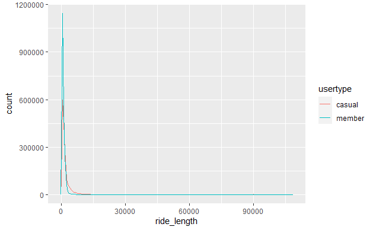

```r
ggplot(data = df2, mapping = aes(x = ride_length)) +
geom_freqpoly(mapping = aes(color = usertype), binwidth = 500)
```

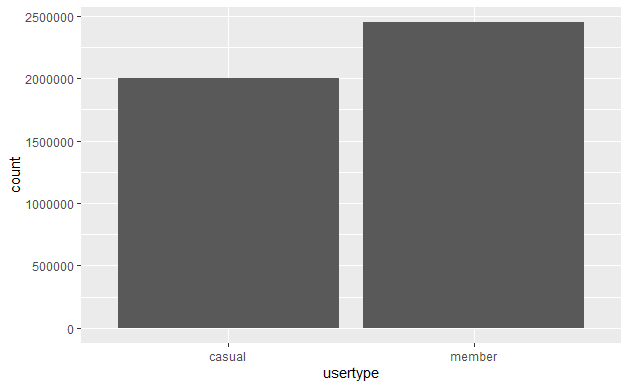

```r
ggplot(df2) +
  geom_bar(mapping = aes(x = usertype))
```

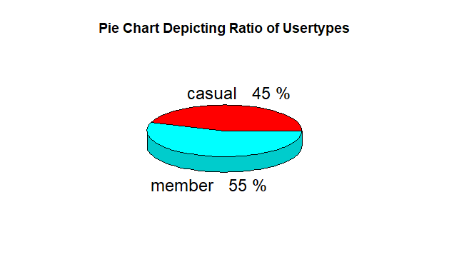

```r
# Distribution of the usertypes
a=table(df2$usertype)
pct=round(a/sum(a)*100)
lbs=paste(c("casual","member")," ",pct,"%",sep=" ")
library(plotrix)
pie3D(a,labels=lbs, main="Pie Chart Depicting Ratio of Usertypes")
```

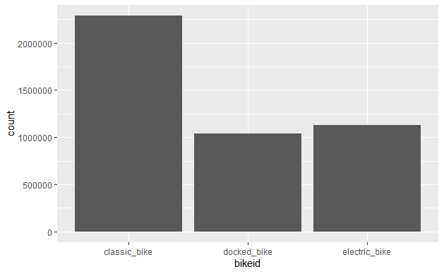

```r
ggplot(df2) +
geom_bar(mapping = aes(x = bikeid))
```

```r
# Create the function.
getmode <- function(v) {
   uniqv <- unique(v)
   uniqv[which.max(tabulate(match(v, uniqv)))]
}
# Calculate the mode using the user function.
result <- getmode(df2$day_of_week)
print("The mode of the day of the week:")
```

```
[1] "The mode of the day of the week:"
```

```r
print(result)
```

```
[1] Saturday
7 Levels: Sunday < Monday < Tuesday < Wednesday < Thursday < ... < Saturday
```

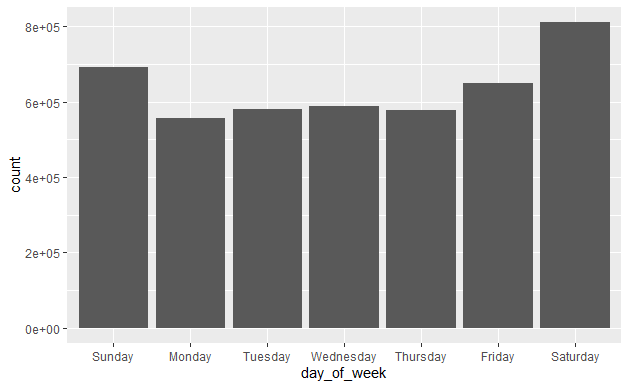

```r
ggplot(df2) +
geom_bar(mapping = aes(x = day_of_week))
```

```r
# Statistical summary of the dataframe
summary(df2)
```

```
   trip_id             bikeid            start_time
 Length:4456632     Length:4456632     Min.   :2020-09-01 00:00:07
 Class :character   Class :character   1st Qu.:2020-12-03 18:40:16
 Mode  :character   Mode  :character   Median :2021-05-24 12:00:14
                                       Mean   :2021-04-08 23:29:07
                                       3rd Qu.:2021-07-16 13:08:15
                                       Max.   :2021-08-31 23:59:35

    end_time                   from_station_name  to_station_name
 Min.   :2020-09-01 00:04:43   Length:4456632     Length:4456632
 1st Qu.:2020-12-03 18:54:02   Class :character   Class :character
 Median :2021-05-24 12:25:37   Mode  :character   Mode  :character
 Mean   :2021-04-08 23:51:05
 3rd Qu.:2021-07-16 13:29:07
 Max.   :2021-09-01 17:37:35

   usertype         ride_length          day_of_week
 Length:4456632     Length:4456632    Sunday   :692042
 Class :character   Class :difftime   Monday   :557406
 Mode  :character   Mode  :numeric    Tuesday  :581026
                                      Wednesday:588735
                                      Thursday :577513
                                      Friday   :648738
                                      Saturday :811172
 ride_length_hms
 Min.   :0S
 1st Qu.:7M 18S
 Median :12M 57S
 Mean   :21M 57.4806656686035S
 3rd Qu.:23M 32S
 Max.   :1d 5H 58M 37S
```

The Data has 4.45 million rows of bike trip data with the minimum ride length of 0s and maximum length of 1d 5H 58m

```r
# Compare usertype
# Compare members and casual users
aggregate(df2$ride_length ~ df2$usertype, FUN = mean)
```

| df2$usertype | df2$ride_length |
| --- | --- |
| casual | 1873.9107 secs |
| member | 862.1613 secs |

```r
aggregate(df2$ride_length ~ df2$usertype, FUN = median)
```

| df2$usertype | df2$ride_length |
| --- | --- |
| casual | 1055 secs |
| member | 618 secs |

```r
aggregate(df2$ride_length ~ df2$usertype, FUN = max)
```

| df2$usertype | df2$ride_length |
| --- | --- |
| casual | 107917 secs |
| member | 101099 secs |

```r
aggregate(df2$ride_length ~ df2$usertype, FUN = min)
```

| df2$usertype | df2$ride_length |
| --- | --- |
| casual | 0 secs |
| member | 0 secs |

```r
NA
NA
```

```r
# Now, let's run the average ride time by each day for members vs casual users
aggregate(df2$ride_length ~ df2$usertype + df2$day_of_week, FUN = mean)
```

| df2$usertype | df2$day_of_week | df2$ride_length |
| --- | --- | --- |
| casual | Sunday | 2120.3700 secs |
| member | Sunday | 974.3582 secs |
| casual | Monday | 1890.2197 secs |
| member | Monday | 832.1529 secs |
| casual | Tuesday | 1715.2734 secs |
| member | Tuesday | 812.3073 secs |
| casual | Wednesday | 1650.5763 secs |
| member | Wednesday | 815.6530 secs |
| casual | Thursday | 1630.3140 secs |
| member | Thursday | 809.1883 secs |

[output cut: 4 more lines]

```r
# analyze ridership data by type and weekday
df2 %>%
  mutate(weekday = wday(start_time, label = TRUE)) %>%  #creates weekday field using wday()
  group_by(usertype, weekday) %>%  #groups by usertype and weekday
  summarise(number_of_rides = n()                           #calculates the number of rides and average duration
            ,average_duration = mean(ride_length)) %>%      # calculates the average duration
  arrange(usertype, weekday)
```

| usertype | weekday | number_of_rides | average_duration |
| --- | --- | --- | --- |
| casual | Sun | 385243 | 2120.3700 secs |
| casual | Mon | 224187 | 1890.2197 secs |
| casual | Tue | 214982 | 1715.2734 secs |
| casual | Wed | 215525 | 1650.5763 secs |
| casual | Thu | 220342 | 1630.3140 secs |
| casual | Fri | 288413 | 1762.7329 secs |
| casual | Sat | 456934 | 2025.7379 secs |
| member | Sun | 306799 | 974.3582 secs |
| member | Mon | 333219 | 832.1529 secs |
| member | Tue | 366044 | 812.3073 secs |

[output cut: 4 more lines]

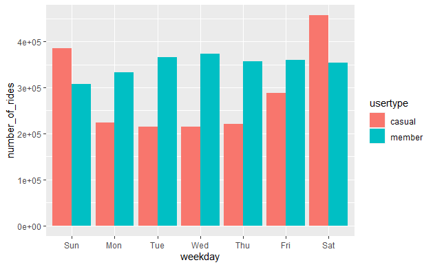

```r
# Let's visualize the number of rides by rider type
df2 %>%
  mutate(weekday = wday(start_time, label = TRUE)) %>%
  group_by(usertype, weekday) %>%
  summarise(number_of_rides = n()
            ,average_duration = mean(ride_length)) %>%
  arrange(usertype, weekday)  %>%
  ggplot(aes(x = weekday, y = number_of_rides, fill = usertype)) +
  geom_col(position = "dodge")
```

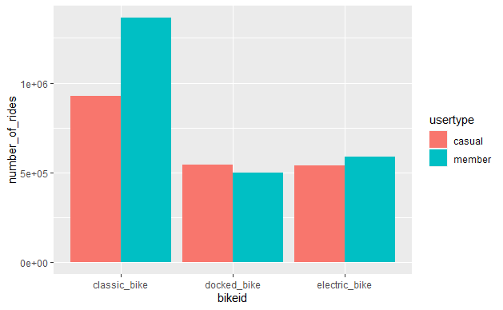

```r
# Let's visualize the number of rides by rider type
df2 %>%
  group_by(usertype, bikeid) %>%
  summarise(number_of_rides = n()
            ,average_duration = mean(ride_length)) %>%
  arrange(usertype, bikeid)  %>%
  ggplot(aes(x = bikeid, y = number_of_rides, fill = usertype)) +
  geom_col(position = "dodge")
```

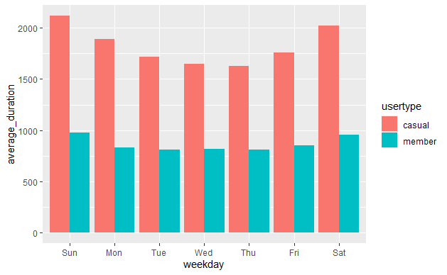

```r
# Let's create a visualization for average duration
df2 %>%
  mutate(weekday = wday(start_time, label = TRUE)) %>%
  group_by(usertype, weekday) %>%
  summarise(number_of_rides = n()
            ,average_duration = mean(ride_length)) %>%
  arrange(usertype, weekday)  %>%
  ggplot(aes(x = weekday, y = average_duration, fill = usertype)) +
  geom_col(position = "dodge")
```

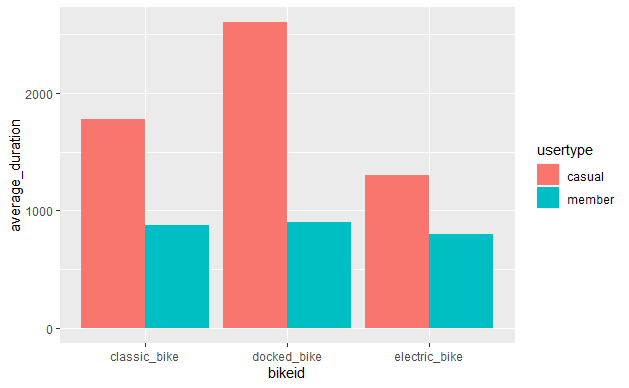

```r
# Let's create a visualization for average duration
df2 %>%
  group_by(usertype, bikeid) %>%
  summarise(number_of_rides = n()
            ,average_duration = mean(ride_length)) %>%
  arrange(usertype, bikeid)  %>%
  ggplot(aes(x = bikeid, y = average_duration, fill = usertype)) +
  geom_col(position = "dodge")
```

### STEP 5 - Save cleaned dataframe for futher analysis

```r
csv_path <- "C:/Users/lanre/Desktop/R/Bike Data/processed_datasets/bike_trips_cleaned.csv"

 write.csv(df2, file = csv_path)
```

## Conclusion and Recommendations

Casual riders usually spend longer time using the bikes than annual members although annual members take a higher number of rides during the weekday. Both user type predominantly use the classic bikes with annual member using higher proportion than casual riders. Irrespective of the bike type used, annual member tend to spend roughly the same amount of time on the bikes but casual members spend more time using the docked bikes.

Based on the insights from this brief exploratory analysis, I would recommend the following:

1. Cyclistics should provide more classic bikes because of its high demand
2. Provide casual riders with insentives to encourage them to upgrade to the annual membership because they spend longer time using the bikes throughout the week.
3. Increase the number of bikes available for users during the weekend because more trips are expected during that period.